# Data Science Final Project - Phish

Ido Algom & Natalie Gilboa

10 March 2017

[figure not shown]

## Abstract

Phish is an American rock and roll band noted for their musical improvisation, extended jams, blending of musical genres, and dedicated fan base. The Band Formed at the University of Vermont in 1983 (with the current line-up solidifying in 1985).

In the following report we’ll show the spreads of songs the band has played over 33 years. We’ll see that there is consistency about songs pick-ups. and most of the songs are played for few years and then stay behind.

Before reading the report it’s important to mention a few facts about Phish shows: 1. A show never repeated itself more than once - Each show offers completely different setlist from another. 2. When the band hits a town it can be for 1 to 4 nights in a row. When it’s 2 it’s called “a Run”. Additional fact number 1 it’s important to mention that a song will never repeat itself more than once in. But important to mention that in rare shows a song can repeat itself more than once at the same show. (sandwich song)

In the report we’ll use song appearances counts and debut years to see how creative the band is. We’ll use k-means to cluster the songs. The reason we chose 3 clusters is that it’s the same amount of eras. (description below)

## Business Understanding

The Mockingbird Foundation is a charitable organization founded by fans of the jam band Phish in 1996 to support music education for children. The website Phish.net is a fan website that formally adopted by The Foundation as a project in 2005. The site had begun in 1991 and served Phish fans for nearly two decades as static HTML pages. It was re-launched as an integrated database - of setlists, song histories, reviews, and more - in fall 2009.

The website contains tables about each song that ever played in show. Every single show the band has been playing during the years has a unique setlist. This information about each song and each show is recorded at the website database for fans.

The report’s targets are made for statistics only. As mentioned, The Mockingbird Foundation is a charitable organization and the band Phish is not related in any way to the organization except in it’s appreciation to their fan base.

## Dictinary

Hiatus - a temporal break-up. Phish went on hiatus 2 times. The first time was on 2001. All the era between 1983 to 2001 is called 1.0 They comeback together about a year later in 2002 until the summer of 2004. This era is called 2.0 and they comeback again to studio and stages in the spring of 2009 until today. this era is 3.0. More words are described in Data understanding.

## Data Understanding

We chose to explore the statistics about the songs. I copied the table about all the songs the band played during the years. The table contains the following columns:

- Song Name
- Original Artist (The band played a lot of cover songs)
- Time Played (At how many shows the song has played)
- Debut (Show date first time played)
- Last Played (Show date last time played)
- Gap (Amount of shows the song hasn’t played)

Let’s get some code - preparations

```r
require(gtable)
require(ggplot2)
library(gtable)
library(ggplot2)
```

Let’s read the file and show the table header

```r
yem <- read.csv("phish.csv",stringsAsFactors = FALSE,colClasses = c(NA,NA,NA,"Date","Date",NA))
head(yem)
```

```
##                Song.Name Original.Artist Times.Played      Debut
## 1            Army of One           Phish           17 2003-07-12
## 2            Bathtub Gin           Phish          247 1989-05-26
## 3                    Bug        Amfibian           63 1999-06-24
## 4 Crosseyed and Painless   Talking Heads           37 1996-10-31
## 5      Down with Disease           Phish          261 1993-12-31
## 6              Farmhouse           Phish           62 1997-11-07
##    Last.Seen Current.Gap
## 1 2016-01-17           0
## 2 2016-01-17           0
## 3 2016-01-17           0
## 4 2016-01-17           0
## 5 2016-01-17           0
## 6 2016-01-17           0
```

Total amount of songs we have:

```r
nrow(yem)
```

```
## [1] 819
```

### Basic Information

How many songs debuted at each day of the week. In this Graph we took the debut day and converted it to Date and to Weekdays with basic R functions.

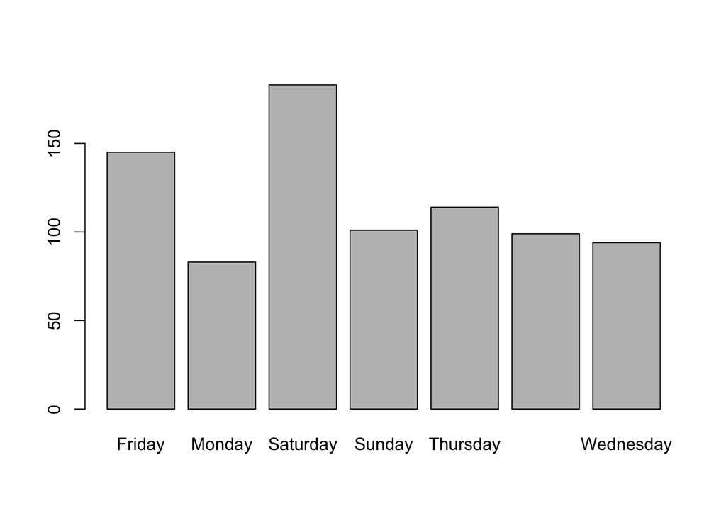

```r
barplot(table(weekdays(as.Date(yem$Debut))))
```

### Songs Left Behind

Some preparations

```r
cover <- format(yem$Original.Artist)
cover2 <- rep("Cover",length(cover))
cover2[grepl("Phish",cover)] <- "Original"
```

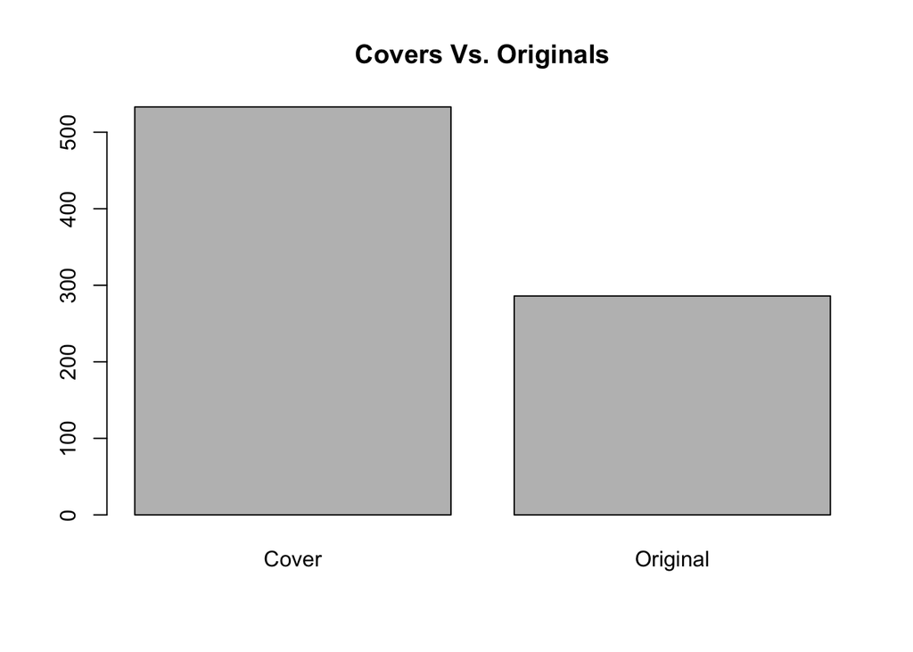

```r
barplot(table(cover2),main = "Covers Vs. Originals")
```

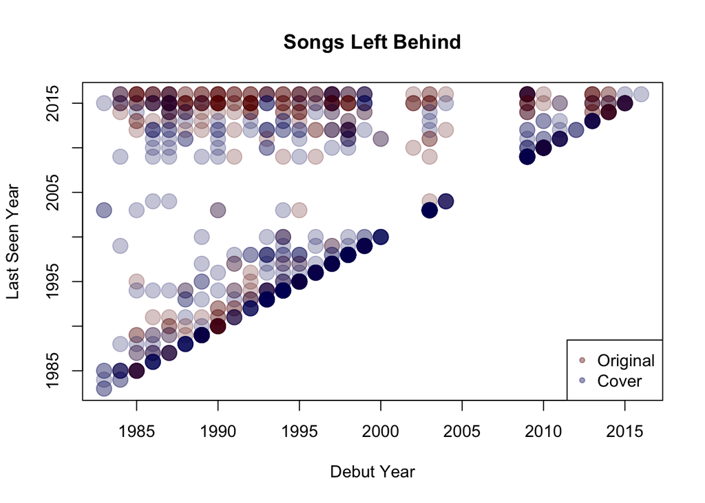

```r
plot(as.numeric(format(as.Date(yem$Debut), "%Y")),as.numeric(format(as.Date(yem$Last.Seen), "%Y")), xlab="Debut Year", ylab="Last Seen Year",main="Songs Left Behind",pch=20,xlim=c(1983,2016),ylim=c(1983,2016), col=ifelse(cover2=="Original", rgb(100,0,0,60,maxColorValue=255),rgb(0,0,100,60,maxColorValue=255)), cex=3)
legend("bottomright",legend =c("Original","Cover"),col=c(rgb(100,0,0,100,maxColorValue=255),rgb(0,0,100,100,maxColorValue=255)),pch=20)
```

### Bust out

A bust out is a sudden song appearance in a show with very big gap. From this plot we can learn most of the originals songs are played very often. Most of the covers don’t make more than few appearance and there are some songs that used to be played often and now they’re gone from the setlist. We can say that as close as a song to p(0,0) the chances to get played at the coming Summer Tour 2016 are higher. As far a song is on the Gap axis as bigger the bust out will be.

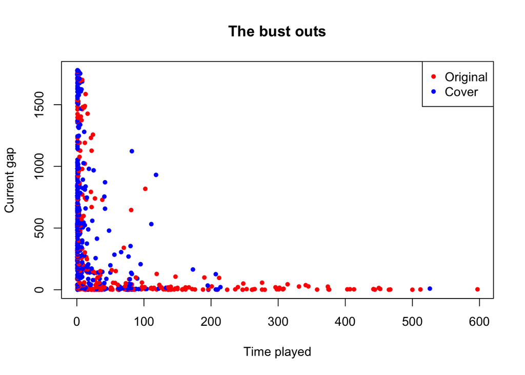

```r
plot(yem$Times.Played,yem$Current.Gap,col=ifelse(cover2=="Original","red","blue"),pch=20,cex=1,main="The bust outs",xlab="Time played",ylab="Current gap")
legend("topright",legend =c("Original","Cover"),col=c("red","blue"),pch=20)
```

## Data Preparation

Right before we’re going to explore our information we’ll create a data frame to include all the information we need. Since we gonna cluster the songs we gonna need to use numerical values. Thus, we gonna take the var yem and change it a little. The data frame fluffhead is gonna include the following vectors:

- Time played - How many times a song has been played live
- Current Gap - How many shows a song hasn’t been played live
- Years since debuted - How many years since this song was debuted live
- Years since last played - How many years the song hasn’t been played live
- is Original- Either the song is originally written by the band or is a cover.

```r
fluffhead = data.frame(
  "time_played" = yem$Times.Played,
  "current_gap" = yem$Current.Gap,
  "years_since_debuted" = floor(as.numeric(as.Date("2017", format="%Y") - yem$Debut)/365.25),
  "years_since_last_played" = floor(as.numeric(as.Date("2017", format="%Y") - yem$Last.Seen)/365.25),
  "is_original" = cover2
)
```

## Modeling

The model we gonna use is clustering model. We’re gonna try to estimate and see groups of songs that left in early era (1.0) and songs that keep popping up at shows. The model will show those those facts from different points of view using K-means algorithm. Each model will be separated by the fact if the song is an original song written by the band or a cover.

Let’s create some k-means models:

The first model we’ll create will try to show how 2 hiatuses (2001,2004) created the 3 eras the band has: 1.0 (1983-2001), 2.0(2002-2004), 3.0 (2009-current):

```r
forbin = kmeans(fluffhead[c("time_played","current_gap","years_since_debuted","years_since_last_played")],3)
```

Let’s compare the clusters with the songs

```r
table(forbin$cluster, fluffhead$is_original)
```

```
##
##     Cover Original
##   1   214       35
##   2   243      214
##   3    76       37
```

## Evaluation

The first evaluation we’ll do is to see clustering the songs by amount of years since debuted and amount of years since last played.

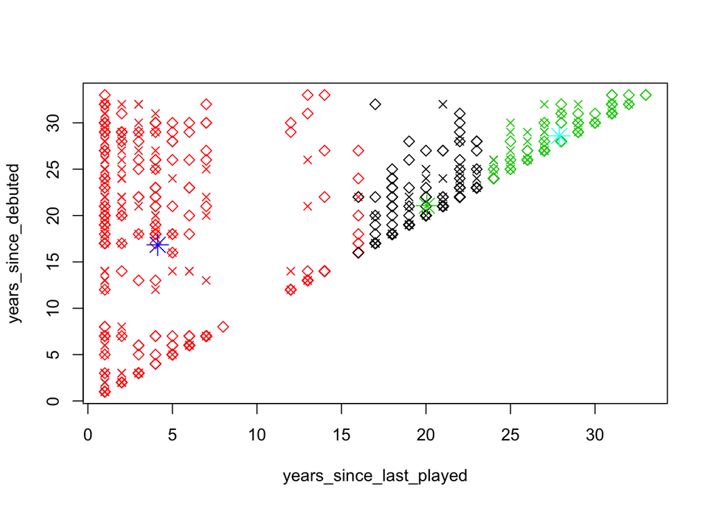

```r
plot(fluffhead[c("years_since_last_played","years_since_debuted")], col= forbin$cluster, pch=ifelse(fluffhead$is_original=="Original",4,5))
points(forbin$centers[,c("years_since_last_played","years_since_debuted")], col=3:5,pch=8,cex=2)
```

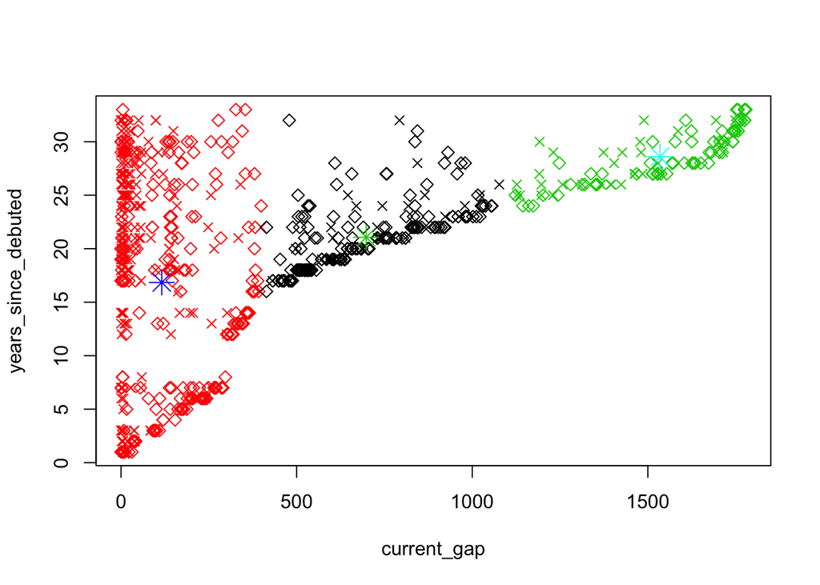

```r
plot(fluffhead[c("current_gap","years_since_debuted")], col= forbin$cluster, pch=ifelse(fluffhead$is_original=="Original",4,5))
points(forbin$centers[,c("current_gap","years_since_debuted")], col=3:5,pch=8,cex=2)
```

In the above plot we replaced the x axis to current_gap. we can see that the point are not going linear anymore. This fact is validating our data as the amount of shows is not linear to years. In order to see this curve we can just show all the songs in on the axis of current gap and years since last played:

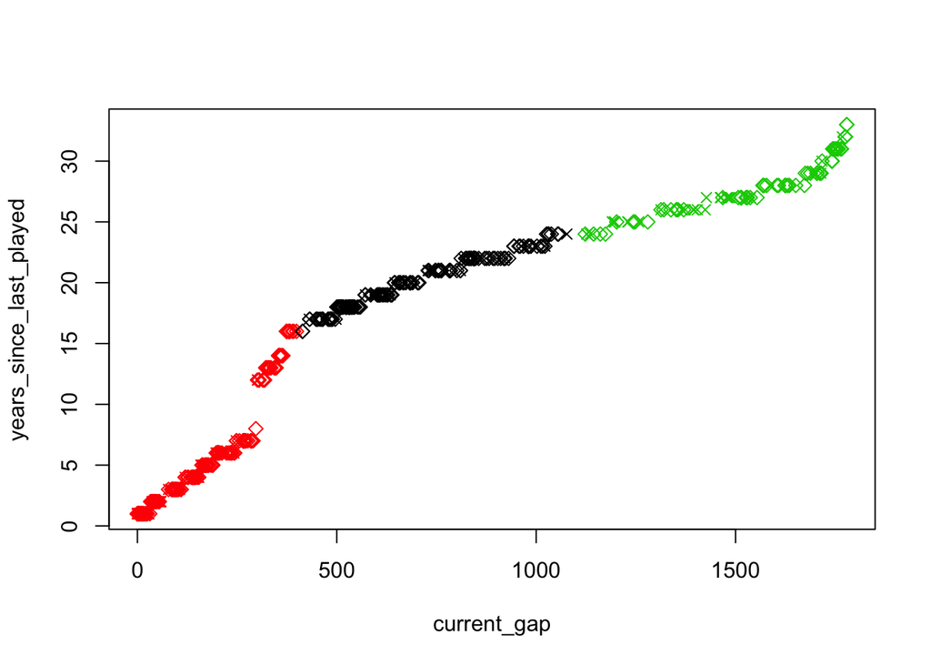

```r
plot(fluffhead[c("current_gap","years_since_last_played")], col= forbin$cluster, pch=ifelse(fluffhead$is_original=="Original",4,5))
```

## Deployment

As mentioned, this project is not about a business. The information we gained from this research may be another way of looking into the way the greatest rock band of all times has chose what to play in their live shows. Thus, the deployment section is not relevant for this report.

## Summary

In the future, if one would like to extend this research it’s possible to insert some jams from various years into signal analyzer (using [psishtrack.com api](http://phishtracks.com)) and take out statistics of the jamming style and see how a jamming style of a song has changed during the years since it’s debut to it’s last performance.

Thanks to the dedicated fanbase of Phish the web is full of information about almost all the shows the band has ever played. The tapers policy contributed in so many ways. Today, out of 2100 shows, more than 2000 are available to immediate streaming for free online. There accurate setlist of each show ( a numerous shows are missing from the early 80s) and the way machine learning, data science and deep learning can take place with all that information is more than interesting for future researches.

## Bibliography

- The database - [Phish.net](http://phish.net/song)
- [Wikipedia](https://en.wikipedia.org/wiki/Phish)
- My knowledge and dozens of shows attendances.

Self-Note - Phish is the greatest band for me. A band that changed my entire life and made the person I am. Ido